# Unit 1 - Assignment

1. Calculate the following
1. ∑(a=5, a=100) (a^4 + 5a^3) with and without loop

```r
# with loop
a <- seq(5,100)
sum = 0
for (i in a) {
  sum = sum + (i^4 + 5*(i^3))
}
sum
```

```
[1] 2177844976
```

```r
# without loop
a <- seq(5,100)
sum(a^4 + 5*(a^3))
```

```
[1] 2177844976
```

2. calculate U40 which is a series, Un = U(n-1) + U(n-2), with U1 = 1 and U2 = 2 ?

```r
first = 1
second = 2
d <- second - first   # common difference
n = 40
U = d*(n-1) + d*(n-2)
U
```

```
[1] 77
```

3. write a program to calculate cosx, sinx (Taylor series). Get the input(x) from the user and n=45

```r
# cosx (Taylor series)
library(pracma)
n <- 45
x <- readline(prompt = "Enter value of x: ")
50
x <- as.integer(x)
# x = 50
# numerical deviatives of order 'n' should be lesser than 'n=8'
taylor(cos, x, n=4)
```

```
[1]  4.020771e-02 -8.085273e+00  6.091927e+02 -2.038332e+04  2.555461e+05
```

```r
# sinx (Taylor series)
library(pracma)
n <- 45
x <- as.integer(readline(prompt = "Enter value of x: "))
70
# x = 70
# numerical deviatives of order 'n' should be lesser than 'n=8'
taylor(sin, x, n=5)
```

```
[1]  8.333275e-03 -2.884400e+00  3.991961e+02 -2.761332e+04  9.546714e+05
[6] -1.319724e+07
```

4. create a vector of the values of e^x cos(x) at x = 3, 3.1, 3.2, …, 6

```r
x <- seq(3, 6, by=0.1)
res <- exp(x) * cos(x)
res
```

```
 [1] -19.884531 -22.178753 -24.490697 -26.773182 -28.969238 -31.011186 -32.819775
 [8] -34.303360 -35.357194 -35.862834 -35.687732 -34.685042 -32.693695 -29.538816
[15] -25.032529 -18.975233 -11.157417  -1.362099  10.632038  25.046705  42.099201
[22]  61.996630  84.929067 111.061586 140.525075 173.405776 209.733494 249.468441
[29] 292.486707 338.564378 387.360340
```

5. x<-1:300. How many numbers in x are divisible by 2? (Use mmodolo operator %%)

```r
x <- 1:300
count = 0
for(n in x) {
  if (n%%2 == 0) {
    count = count+1
  }
}
count
```

```
[1] 150
```

2. Solve the following system of linear equations using Gaussian elimination (Ax = y)  
   x + 2y +3x = 9  
   2x - y + 2x = -3  
   3x + 3y + z = 5

```r
library(matlib)
A <- matrix(c(1, 2, 3, 2, -1, 2, 3, 3, 1), 3, 3, byrow=TRUE)
b <- c(9, -3, 5)
res <- gaussianElimination(A, b)
res
```

```
     [,1] [,2] [,3]      [,4]
[1,]    1    0    0 -1.750000
[2,]    0    1    0  2.857143
[3,]    0    0    1  1.678571
```

```r
cat("The result of x =", res[10],", y =", res[11], ", z =", res[12])
```

```
The result of x = -1.75 , y = 2.857143 , z = 1.678571
```

3. Use outer function to create the following matrix  
   0 1 2 3 4  
   1 2 3 4 5  
   2 3 4 5 6  
   3 4 5 6 7  
   4 5 6 7 8

```r
r <- 0:4
c <- 0:4
outer(r, c, "+")
```

```
     [,1] [,2] [,3] [,4] [,5]
[1,]    0    1    2    3    4
[2,]    1    2    3    4    5
[3,]    2    3    4    5    6
[4,]    3    4    5    6    7
[5,]    4    5    6    7    8
```

4. Get the COVID-19 Dataset from the data sources. Number of observations should be more than 100. Then, report the following information:
1. Data Source detail (Ex: link)
2. Explain the Unit and Neccessity of each variable
3. Find the missing values (rows & columns) and replace them with mean (Tidy Dataset)
4. Generate the two new variables (Var1: mean, Var2: median from available variable)
5. Rename the two existing variables
6. Create a plot using the following instructions (using 7 layers of Grammar of Graphics)
   1. Choose x and y axis(ase)
   2. geom_point() - specify the parameters, size:5, color:red, alpha:1/5
   3. Use Facet grid, cartesian coordinates & geom_smooth()
   4. Assign the title to x, y, and graph
   5. Export the graph to your working directory with the title called “covid_19_dataset.png”

```r
# a. Data Source detail
# Dataset on COVID-19 in Brazil
# Author: Raphael Fontes
# URL: https://www.kaggle.com/unanimad/corona-virus-brazil
library(tidyverse)
dataset <- read.csv("brazil_covid19.csv")
datasetBrazil <- dataset
datasetBrazil
```

| date | region | state | cases | deaths |
| --- | --- | --- | --- | --- |
| 2020-02-25 | Centro-Oeste | DF | 0 | 0 |
| 2020-02-25 | Centro-Oeste | GO | 0 | 0 |
| 2020-02-25 | Centro-Oeste | MS | 0 | 0 |
| 2020-02-25 | Centro-Oeste | MT | 0 | 0 |
| 2020-02-25 | Nordeste | AL | 0 | 0 |
| 2020-02-25 | Nordeste | BA | 0 | 0 |
| 2020-02-25 | Nordeste | CE | 0 | 0 |
| 2020-02-25 | Nordeste | MA | 0 | 0 |
| 2020-02-25 | Nordeste | PB | 0 | 0 |
| 2020-02-25 | Nordeste | PE | 0 | 0 |

[output cut: 990 more lines]

2. Explain the Unit and Neccessity of each variable

This dataset has 5 variables:  
- date: define date of confirmation  
- region: define the region of state  
- state: define state of the Brazil  
- cases: define the number of confirmed cases  
- deaths: define the number of deaths

```r
names(datasetBrazil)
```

```
[1] "date"   "region" "state"  "cases"  "deaths"
```

3. Find the missing values (rows & columns) and replace them with mean (Tidy Dataset)

```r
datasetBrazil[] <- lapply(datasetBrazil, function(x) {
  x[is.na(x)] <- mean(x, na.rm = TRUE)
})
```

```
argument is not numeric or logical: returning NAargument is not numeric or logical: returning NAargument is not numeric or logical: returning NA
```

```r
dataset
```

| date | region | state | cases | deaths |
| --- | --- | --- | --- | --- |
| 2020-02-25 | Centro-Oeste | DF | 0 | 0 |
| 2020-02-25 | Centro-Oeste | GO | 0 | 0 |
| 2020-02-25 | Centro-Oeste | MS | 0 | 0 |
| 2020-02-25 | Centro-Oeste | MT | 0 | 0 |
| 2020-02-25 | Nordeste | AL | 0 | 0 |
| 2020-02-25 | Nordeste | BA | 0 | 0 |
| 2020-02-25 | Nordeste | CE | 0 | 0 |
| 2020-02-25 | Nordeste | MA | 0 | 0 |
| 2020-02-25 | Nordeste | PB | 0 | 0 |
| 2020-02-25 | Nordeste | PE | 0 | 0 |

[output cut: 990 more lines]

4. Generate the two new variables (Var1: mean, Var2: median from available variable)

```r
dataset %>% mutate(Mean = mean(cases), Median = median(cases))
```

| date | region | state | cases | deaths | Mean | Median |
| --- | --- | --- | --- | --- | --- | --- |
| 2020-02-25 | Centro-Oeste | DF | 0 | 0 | 88982.26 | 44153 |
| 2020-02-25 | Centro-Oeste | GO | 0 | 0 | 88982.26 | 44153 |
| 2020-02-25 | Centro-Oeste | MS | 0 | 0 | 88982.26 | 44153 |
| 2020-02-25 | Centro-Oeste | MT | 0 | 0 | 88982.26 | 44153 |
| 2020-02-25 | Nordeste | AL | 0 | 0 | 88982.26 | 44153 |
| 2020-02-25 | Nordeste | BA | 0 | 0 | 88982.26 | 44153 |
| 2020-02-25 | Nordeste | CE | 0 | 0 | 88982.26 | 44153 |
| 2020-02-25 | Nordeste | MA | 0 | 0 | 88982.26 | 44153 |
| 2020-02-25 | Nordeste | PB | 0 | 0 | 88982.26 | 44153 |
| 2020-02-25 | Nordeste | PE | 0 | 0 | 88982.26 | 44153 |

[output cut: 990 more lines]

5. Rename the two existing variables

```r
dataset %>% rename(sick = cases, dead = deaths)
```

| date | region | state | sick | dead |
| --- | --- | --- | --- | --- |
| 2020-02-25 | Centro-Oeste | DF | 0 | 0 |
| 2020-02-25 | Centro-Oeste | GO | 0 | 0 |
| 2020-02-25 | Centro-Oeste | MS | 0 | 0 |
| 2020-02-25 | Centro-Oeste | MT | 0 | 0 |
| 2020-02-25 | Nordeste | AL | 0 | 0 |
| 2020-02-25 | Nordeste | BA | 0 | 0 |
| 2020-02-25 | Nordeste | CE | 0 | 0 |
| 2020-02-25 | Nordeste | MA | 0 | 0 |
| 2020-02-25 | Nordeste | PB | 0 | 0 |
| 2020-02-25 | Nordeste | PE | 0 | 0 |

[output cut: 990 more lines]

6. Create a plot using the following instructions (using 7 layers of Grammar of Graphics)
   1. Choose x and y axis(ase)  
      choose date as ‘x’ and deaths as ‘y’

```r
data <- dataset %>% count(date, wt = deaths)
date <- data[['date']]
deaths <- data[['n']]
data
```

| date | n |
| --- | --- |
| 2020-02-25 | 0 |
| 2020-02-26 | 0 |
| 2020-02-27 | 0 |
| 2020-02-28 | 0 |
| 2020-02-29 | 0 |
| 2020-03-01 | 0 |
| 2020-03-02 | 0 |
| 2020-03-03 | 0 |
| 2020-03-04 | 0 |
| 2020-03-05 | 0 |

[output cut: 270 more lines]

```
  ii. geom_point() - specify the parameters, size:5, color:red, alpha:1/5
```

```r
library(ggplot2)
geoPoint = geom_point(alpha = 1/5, color = "red", size = 5)
geoPoint
```

```
geom_point: na.rm = FALSE
stat_identity: na.rm = FALSE
position_identity
```

```r
plot <- ggplot(x = data, mapping = aes(x = date, y = deaths)) + geoPoint
plot
```

[output not shown]

```
  iii. Use Facet grid, cartesian coordinates & geom_smooth()
```

[figure not shown]

```r
# facet grid
plot + facet_grid(deaths)
```

```r
# cartesian coordinates
plot + coord_cartesian(expand = TRUE)
```

[output not shown]

```r
# geom_smooth()
plot + geom_smooth()
```

[output not shown]

```
  iv. Assign the title to x, y, and graph
```

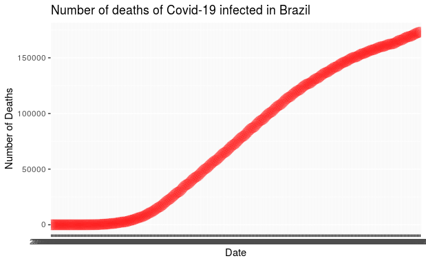

```r
plot <- plot + ggtitle("Number of deaths of Covid-19 infected in Brazil") +
  xlab("Date") + ylab("Number of Deaths")
plot
```

```
  v. Export the graph to your working directory with the title called "covid_19_dataset.png"
```

```r
ggsave("covid_19_dataset.png", width = 25, height = 25, units = "cm")
```